# Introduction to R - Exercises

CCDL for ALSF

2020

The goal of these exercises is to help you get comfortable with using R and R notebooks by continuing to play with the gene results dataset we used in the `01-intro_to_base_R` and `02-intro_to_ggplot2` notebooks. It is a pre-processed [astrocytoma microarray dataset](https://www.refine.bio/experiments/GSE44971/gene-expression-data-from-pilocytic-astrocytoma-tumour-samples-and-normal-cerebellum-controls) on which we performed a set of differential expression analyses.

### Set Up

Use this chunk to load the `tidyverse` package.

```r
library(tidyverse)
```

We’ll want to establish a directory called `results/` to save our results from this exercise. In the following chunk, ensure that this directory exists as follows:

- First, define a variable `results_dir` with the value `"results"`. This is the name of the directory we’ll create.
- Next, create this directory with `fs::dir_create()`. Note that this function will not do anything if that directory already exists, so it is safe to run anytime.

```r
# define a results_dir variable
results_dir <- "results"
# create the results directory
fs::dir_create(results_dir)
```

## Read in the gene results file

Use `readr::read_tsv()` to read in the file “gene_results_GSE44971.tsv” and assign it the variable `stats_df`. Recall that this notation means the `read_tsv()` function from the `readr` package. If you have already loaded the `tidyverse` package above with `library()`, you can use the function `read_tsv()` on its own without the preceding `readr::` as the `readr` package is loaded as part of `tidyverse`.

```r
stats_df <- read_tsv("data/gene_results_GSE44971.tsv")
```

Use this chunk to explore what your data frame, `stats_df` looks like.

```r
view(stats_df)
```

## Read in the metadata

Use `readr::read_tsv()` to read in the file “cleaned_metadata_GSE44971.tsv” and assign it the name `metadata`.

```r
metadata <- read_tsv("data/cleaned_metadata_GSE44971.tsv")
```

Use this chunk to explore what your data frame, `metadata` looks like.

```r
metadata
```

| sample_id | sex | tissue | brain_location | title |
| --- | --- | --- | --- | --- |
| GSM1094830 | male | pilocytic_astrocytoma | Cerebellum | PA_17 |
| GSM1094853 | male | pilocytic_astrocytoma | Cerebellum | PA_68 |
| GSM1094846 | female | pilocytic_astrocytoma | Cerebellum | PA_64 |
| GSM1094869 | male | normal_cerebellum_control | Cerebellum | CTRL_CBM_13 |
| GSM1094826 | male | pilocytic_astrocytoma | Cerebellum | PA_12 |
| GSM1094821 | female | pilocytic_astrocytoma | Cerebellum | PA_06 |
| GSM1094848 | male | pilocytic_astrocytoma | Fourth Ventricle | PA_44 |
| GSM1094845 | female | pilocytic_astrocytoma | Cerebellum | PA_37 |
| GSM1094824 | male | pilocytic_astrocytoma | Cerebral hemisphere | PA_10 |
| GSM1094840 | male | pilocytic_astrocytoma | Cerebellum | PA_28 |

[output cut: 48 more lines]

### Selecting from data frames

Use `$` syntax to look at the `avg_expression` column of the `stats_df` data frame.

```r
stats_df$avg_expression
```

```
   [1]   8.361818  10.500009   5.923962  12.328982  12.001801  19.084011   8.453933   5.116563   6.345609  25.473133
  [11]  38.866912   5.613841   7.539868  12.052861  24.832742   7.568481   7.765075  12.116466   5.185520   9.674196
  [21]   8.880052   5.420666   8.545795   5.860617  25.752680   6.731484  17.466032   9.638069  10.598742   6.152062
  [31]  22.682215   9.150479   5.126262  17.137658  16.342516  10.083913  16.985986   9.718591   9.103716   5.069792
  [41]  13.123381  19.842813   5.719139   6.099870   8.171732  10.560318  28.484791   7.565464   8.466025   6.892540
  [51]   7.548145  31.617065  17.325848   5.265291   8.989985  18.990736   9.652945  19.483830   7.709459 123.274072
  [61]  13.866606   6.895693   5.701373   8.037877  10.107804   5.784972 108.879096  45.722196   6.202930  17.501360
  [71]   5.622557  13.216234  21.520975   5.200199   8.348036  13.462684   6.288637  11.800851   7.242380   8.429338
  [81]  74.855947   7.651266  14.237903   7.152891  19.720394   8.032124   6.219822   6.216832   6.300073  15.839722
  [91]   6.144279  36.231807   6.227449   6.539284  13.724301   5.268595   6.032535  18.082407   6.271130   7.257099
 [101]   9.137922  17.989419   9.526980  12.822802   9.260171   5.336161   9.144854   9.887260   5.734178   5.593624
 [111]  19.350817   6.114609  12.146190   5.029211   6.908206   5.291812  14.249869   5.958046  12.351702   6.460539
 [121]  11.519997  11.685170   6.739959   6.548658   6.741052   5.111865   7.154151   5.277690   6.794362  24.871654
 [131]  11.389389  11.871443   6.345345   5.360677  29.265036  18.391654  11.813695   7.722354  10.630229   8.517089
 [141]   6.659614   9.423798   5.177819   6.127583  13.222753   5.130129   9.605144   9.877481   6.176327   7.806627
```

[output cut: 86 more lines]

Use the `min()` argument to find what the minimum average expression in this dataset is. Remember you can use `?min` or the help panel to find out more about a function.

```r
# Find the minimum average expression value
min(stats_df$avg_expression)
```

```
[1] 5.00273
```

Find the `log()`, using base 2, of the average expression values.

```r
# Find the log of base 2 of the average expression
log2(stats_df$avg_expression)
```

```
   [1] 3.063817 3.392319 2.566562 3.623982 3.585179 4.254292 3.079623 2.355175 2.665759 4.670905 5.280471 2.488988 2.914539
  [14] 3.591304 4.634172 2.920004 2.957000 3.598897 2.374489 3.274142 3.150568 2.438470 3.095215 2.551053 4.686651 2.750925
  [27] 4.126480 3.268744 3.405821 2.621070 4.503490 3.193847 2.357907 4.099098 4.030558 3.333984 4.086273 3.280747 3.186456
  [40] 2.341927 3.714068 4.310545 2.515798 2.608778 3.030642 3.400581 4.832120 2.919429 3.081685 2.785036 2.916122 4.982632
  [53] 4.114854 2.396513 3.168319 4.247224 3.270969 4.284205 2.946630 6.945726 3.793543 2.785696 2.511309 3.006815 3.337398
  [66] 2.532310 6.766583 5.514823 2.632950 4.129395 2.491226 3.724239 4.427672 2.378567 3.061437 3.750894 2.652747 3.560819
  [79] 2.856464 3.075419 6.226045 2.935699 3.831665 2.838527 4.301617 3.005782 2.636873 2.636180 2.655368 3.985475 2.619244
  [92] 5.179185 2.638641 2.709133 3.778661 2.397418 2.592764 4.176515 2.648725 2.859393 3.191866 4.169077 3.252019 3.680640
 [105] 3.211039 2.415802 3.192960 3.305571 2.519587 2.483783 4.274323 2.612260 3.602432 2.330332 2.788311 2.403762 3.832877
 [118] 2.574839 3.626638 2.691655 3.526068 3.546607 2.752740 2.711199 2.752974 2.353850 2.838781 2.399907 2.764338 4.636431
 [131] 3.509619 3.569423 2.665699 2.422415 4.871106 4.200979 3.562388 2.949041 3.410101 3.090361 2.735439 3.236309 2.372344
 [144] 2.615318 3.724951 2.358995 3.263807 3.304143 2.626749 2.964699 3.271743 4.265162 2.501987 2.936715 3.010173 2.500458
 [157] 2.569169 5.599687 2.513259 3.321628 3.999999 3.552198 2.615319 3.047998 4.925011 2.489222 2.600596 2.696066 3.393511
 [170] 3.028638 3.021121 3.161125 3.041869 3.581702 2.583757 3.178381 3.011567 2.642422 2.460187 3.146611 3.592955 3.129045
 [183] 3.520602 4.034184 2.343479 2.844891 2.344961 4.283343 2.388027 2.926399 4.987597 2.562467 4.660478 3.434799 3.848710
```

[output cut: 63 more lines]

## Using logical arguments

Display the `adj_p_value` column of the `stats_df` data frame.

```r
stats_df$adj_p_value
```

```
   [1] 8.819912e-02 5.827042e-01 7.593400e-01 2.568979e-01 8.489870e-01 9.719743e-01 4.006443e-01 2.003266e-02 9.218008e-01
  [10] 9.016228e-01 9.538240e-01 8.274357e-01 1.215894e-03 9.818779e-01 9.102548e-01 7.574206e-01 1.884726e-01 9.967261e-01
  [19] 9.956960e-01 2.176220e-01 9.936508e-01 9.857383e-01 9.108179e-01 3.497699e-03 8.622627e-01 2.253084e-02 9.377488e-01
  [28] 7.424436e-04 5.146259e-02 1.766911e-01 9.134925e-01 3.764820e-01 3.131592e-01 3.771840e-01 7.602690e-02 3.082712e-01
  [37] 5.226640e-02 1.740315e-03 5.037181e-01 8.497828e-01 9.907849e-01 9.996104e-01 5.720609e-01 9.491368e-01 6.643440e-01
  [46] 9.010374e-01 3.089989e-01 7.349792e-01 1.199005e-01 6.945365e-01 9.020538e-01 7.932306e-01 6.331836e-01 9.814925e-01
  [55] 3.394851e-01 3.308021e-01 8.165594e-01 8.900060e-01 7.231735e-01 2.548743e-01 9.973588e-01 9.646984e-01 5.312386e-02
  [64] 7.743083e-02 2.071664e-01 9.989755e-01 1.034462e-01 5.276504e-01 6.936255e-02 2.845452e-01 8.344574e-01 9.275196e-03
  [73] 5.650340e-01 8.756190e-01 3.471153e-01 8.504832e-01 5.607710e-01 6.206191e-05 2.812004e-01 9.967261e-01 7.255531e-01
  [82] 6.723621e-01 1.294927e-02 7.696287e-01 8.907510e-01 7.001591e-01 1.794229e-03 9.577412e-01 9.212815e-01 9.875853e-01
  [91] 8.247388e-01 3.019219e-01 8.870288e-01 2.475095e-02 6.718299e-01 9.469286e-01 4.455461e-01 2.923023e-01 3.901996e-01
 [100] 5.890914e-01 7.418441e-03 5.762797e-01 8.274357e-01 8.311372e-02 8.053784e-03 9.153442e-01 3.028925e-01 9.414091e-01
 [109] 9.992774e-01 8.607638e-01 6.743586e-01 9.937135e-01 6.735932e-01 3.651102e-01 3.047047e-01 2.813709e-01 9.491995e-01
 [118] 6.420889e-01 8.847346e-02 4.862035e-01 3.167452e-02 9.465984e-01 9.930514e-01 8.655074e-01 9.229769e-01 5.350792e-02
 [127] 7.489426e-01 9.327712e-01 7.351805e-01 6.743586e-01 9.670927e-01 9.967261e-01 2.484910e-02 5.156738e-02 8.373812e-01
```

[output cut: 98 more lines]

Find out which of these adjusted p-values are below a `0.05` cutoff using a logical statement.

```r
stats_df$adj_p_value < 0.05
```

```
   [1] FALSE FALSE FALSE FALSE FALSE FALSE FALSE  TRUE FALSE FALSE FALSE FALSE  TRUE FALSE FALSE FALSE FALSE FALSE FALSE
  [20] FALSE FALSE FALSE FALSE  TRUE FALSE  TRUE FALSE  TRUE FALSE FALSE FALSE FALSE FALSE FALSE FALSE FALSE FALSE  TRUE
  [39] FALSE FALSE FALSE FALSE FALSE FALSE FALSE FALSE FALSE FALSE FALSE FALSE FALSE FALSE FALSE FALSE FALSE FALSE FALSE
  [58] FALSE FALSE FALSE FALSE FALSE FALSE FALSE FALSE FALSE FALSE FALSE FALSE FALSE FALSE  TRUE FALSE FALSE FALSE FALSE
  [77] FALSE  TRUE FALSE FALSE FALSE FALSE  TRUE FALSE FALSE FALSE  TRUE FALSE FALSE FALSE FALSE FALSE FALSE  TRUE FALSE
  [96] FALSE FALSE FALSE FALSE FALSE  TRUE FALSE FALSE FALSE  TRUE FALSE FALSE FALSE FALSE FALSE FALSE FALSE FALSE FALSE
 [115] FALSE FALSE FALSE FALSE FALSE FALSE  TRUE FALSE FALSE FALSE FALSE FALSE FALSE FALSE FALSE FALSE FALSE FALSE  TRUE
 [134] FALSE FALSE FALSE FALSE  TRUE FALSE FALSE FALSE FALSE  TRUE FALSE FALSE FALSE FALSE FALSE FALSE FALSE FALSE FALSE
 [153]  TRUE FALSE  TRUE FALSE FALSE FALSE FALSE FALSE FALSE FALSE  TRUE FALSE FALSE FALSE FALSE FALSE FALSE  TRUE FALSE
 [172] FALSE FALSE FALSE FALSE FALSE FALSE FALSE FALSE FALSE  TRUE FALSE FALSE FALSE FALSE  TRUE FALSE FALSE FALSE FALSE
 [191] FALSE FALSE FALSE FALSE FALSE FALSE FALSE FALSE FALSE FALSE FALSE  TRUE FALSE FALSE FALSE  TRUE FALSE  TRUE FALSE
 [210] FALSE  TRUE FALSE FALSE  TRUE FALSE FALSE FALSE  TRUE FALSE FALSE FALSE FALSE FALSE FALSE FALSE FALSE FALSE FALSE
 [229]  TRUE FALSE FALSE FALSE FALSE FALSE FALSE FALSE FALSE FALSE FALSE FALSE FALSE FALSE FALSE  TRUE FALSE FALSE FALSE
 [248] FALSE FALSE FALSE FALSE FALSE FALSE FALSE FALSE FALSE FALSE  TRUE FALSE FALSE FALSE  TRUE FALSE FALSE FALSE FALSE
 [267] FALSE  TRUE FALSE  TRUE FALSE FALSE FALSE  TRUE FALSE FALSE FALSE FALSE FALSE FALSE FALSE FALSE FALSE  TRUE FALSE
```

[output cut: 39 more lines]

Name the logical vector you created above as `significant_vector`.

```r
significant_vector <- stats_df$adj_p_value < 0.05
```

Use `sum()` with the object `significant_vector` to count how many p values in the total set are below this cutoff. To solve this, you might think about `TRUE` and `FALSE` values as an alternative way to represent `1` and `0`.

```r
sum(significant_vector)
```

```
[1] 1635
```

## Filter the dataset

Select the column `contrast` from `stats_df`.

| contrast |
| --- |
| male_female |
| male_female |
| male_female |
| male_female |
| male_female |
| male_female |
| male_female |
| male_female |
| male_female |
| male_female |

[output cut: 990 more lines]

Construct a logical vector using `contrast` column you selected above that indicates which rows of `stats_df` are from the `astrocytoma_normal` contrast test.

```r
stats_df$contrast == "astrocytoma_normal"
```

```
   [1] FALSE FALSE FALSE FALSE FALSE FALSE FALSE FALSE FALSE FALSE FALSE FALSE FALSE FALSE FALSE FALSE FALSE FALSE FALSE FALSE
  [21] FALSE FALSE FALSE FALSE FALSE FALSE FALSE FALSE FALSE FALSE FALSE FALSE FALSE FALSE FALSE FALSE FALSE FALSE FALSE FALSE
  [41] FALSE FALSE FALSE FALSE FALSE FALSE FALSE FALSE FALSE FALSE FALSE FALSE FALSE FALSE FALSE FALSE FALSE FALSE FALSE FALSE
  [61] FALSE FALSE FALSE FALSE FALSE FALSE FALSE FALSE FALSE FALSE FALSE FALSE FALSE FALSE FALSE FALSE FALSE FALSE FALSE FALSE
  [81] FALSE FALSE FALSE FALSE FALSE FALSE FALSE FALSE FALSE FALSE FALSE FALSE FALSE FALSE FALSE FALSE FALSE FALSE FALSE FALSE
 [101] FALSE FALSE FALSE FALSE FALSE FALSE FALSE FALSE FALSE FALSE FALSE FALSE FALSE FALSE FALSE FALSE FALSE FALSE FALSE FALSE
 [121] FALSE FALSE FALSE FALSE FALSE FALSE FALSE FALSE FALSE FALSE FALSE FALSE FALSE FALSE FALSE FALSE FALSE FALSE FALSE FALSE
 [141] FALSE FALSE FALSE FALSE FALSE FALSE FALSE FALSE FALSE FALSE FALSE FALSE FALSE FALSE FALSE FALSE FALSE FALSE FALSE FALSE
 [161] FALSE FALSE FALSE FALSE FALSE FALSE FALSE FALSE FALSE FALSE FALSE FALSE FALSE FALSE FALSE FALSE FALSE FALSE FALSE FALSE
 [181] FALSE FALSE FALSE FALSE FALSE FALSE FALSE FALSE FALSE FALSE FALSE FALSE FALSE FALSE FALSE FALSE FALSE FALSE FALSE FALSE
 [201] FALSE FALSE FALSE FALSE FALSE FALSE FALSE FALSE FALSE FALSE FALSE FALSE FALSE FALSE FALSE FALSE FALSE FALSE FALSE FALSE
 [221] FALSE FALSE FALSE FALSE FALSE FALSE FALSE FALSE FALSE FALSE FALSE FALSE FALSE FALSE FALSE FALSE FALSE FALSE FALSE FALSE
 [241] FALSE FALSE FALSE FALSE FALSE FALSE FALSE FALSE FALSE FALSE FALSE FALSE FALSE FALSE FALSE FALSE FALSE FALSE FALSE FALSE
 [261] FALSE FALSE FALSE FALSE FALSE FALSE FALSE FALSE FALSE FALSE FALSE FALSE FALSE FALSE FALSE FALSE FALSE FALSE FALSE FALSE
 [281] FALSE FALSE FALSE FALSE FALSE FALSE FALSE FALSE FALSE FALSE FALSE FALSE FALSE FALSE FALSE FALSE FALSE FALSE FALSE FALSE
```

[output cut: 36 more lines]

Use `dplyr::filter()` to keep only the data for the `astrocytoma_normal` contrast in `stats_df`.

| ensembl_id | gene_symbol | contrast | log_fold_change | avg_expression | t_statistic | p_value | adj_p_value |
| --- | --- | --- | --- | --- | --- | --- | --- |
| ENSG00000000003 | TSPAN6 | astrocytoma_normal | 0.90600777 | 8.361818 | 0.64623513 | 5.208220e-01 | 6.250737e-01 |
| ENSG00000000419 | DPM1 | astrocytoma_normal | 0.46085124 | 10.500009 | 0.51520642 | 6.084791e-01 | 7.019647e-01 |
| ENSG00000001561 | ENPP4 | astrocytoma_normal | 3.11203310 | 5.923962 | 3.09126168 | 3.129815e-03 | 9.579057e-03 |
| ENSG00000001629 | ANKIB1 | astrocytoma_normal | 0.95888170 | 12.328982 | 0.68630241 | 4.954136e-01 | 6.020367e-01 |
| ENSG00000002549 | LAP3 | astrocytoma_normal | 5.64814777 | 12.001801 | 2.52450357 | 1.450970e-02 | 3.445495e-02 |
| ENSG00000002586 | CD99 | astrocytoma_normal | 11.72906414 | 19.084011 | 3.05967493 | 3.425070e-03 | 1.033758e-02 |
| ENSG00000002834 | LASP1 | astrocytoma_normal | 0.15624763 | 8.453933 | 0.19375451 | 8.470839e-01 | 8.923323e-01 |
| ENSG00000003096 | KLHL13 | astrocytoma_normal | -4.30350359 | 5.116563 | -3.86975253 | 2.917735e-04 | 1.281886e-03 |
| ENSG00000004059 | ARF5 | astrocytoma_normal | -6.09917714 | 6.345609 | -5.89530205 | 2.393197e-07 | 2.860427e-06 |
| ENSG00000004779 | NDUFAB1 | astrocytoma_normal | -2.70656218 | 25.473133 | -0.91006867 | 3.667684e-01 | 4.767894e-01 |

[output cut: 990 more lines]

Use the `nrow()` function on `astrocytoma_normal_df` to see if your filter worked. You should have `2268` rows.

```r
nrow(astrocytoma_normal_df)
```

```
[1] 2268
```

Save your filtered data to a TSV file using `readr::write_tsv()`. Call it `astrocytoma_normal_contrast_results.tsv` and save it to the `results` directory.

### Create a density plot

Set up a ggplot object for `astrocytoma_normal_df` and set `x` as the average expression variable. Use the `+` to add on a layer called `geom_density()`

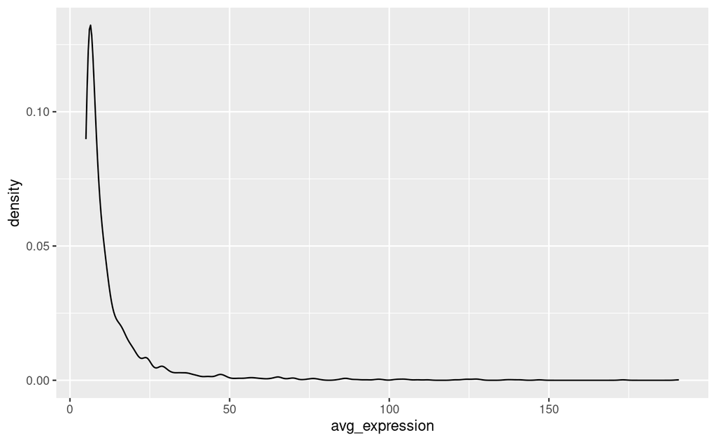

Use the plot you started above and add a `ggplot2::theme` layer to play with its aesthetics (e.g. `theme_classic()`) See the [ggplot2 themes vignette](https://ggplot2.tidyverse.org/reference/ggtheme.html) to see a list of theme options.

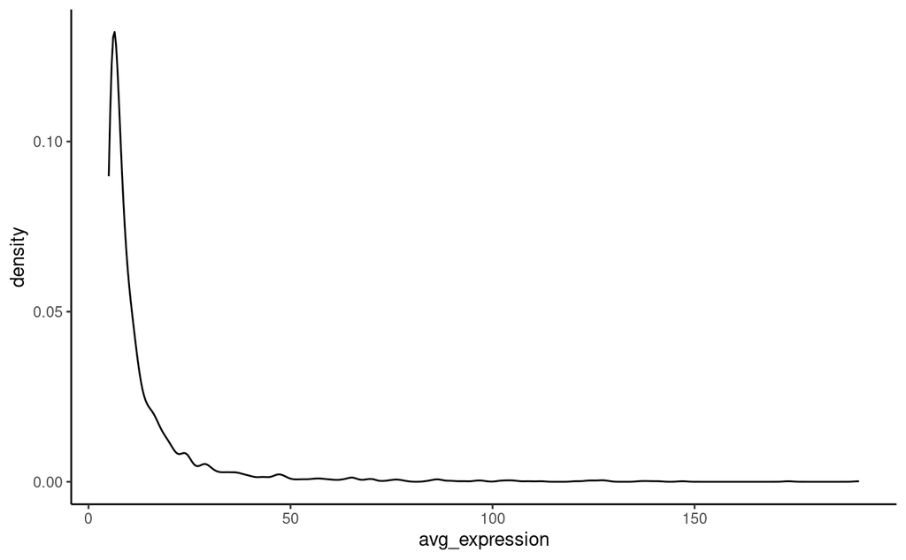

Feel free to make other customizations to this plot by adding more layers with `+`. You can start by adding labels with the function `labs()`, and then by getting inspiration from this [handy cheatsheet for ggplot2 (PDF)](https://raw.githubusercontent.com/rstudio/cheatsheets/main/data-visualization.pdf).

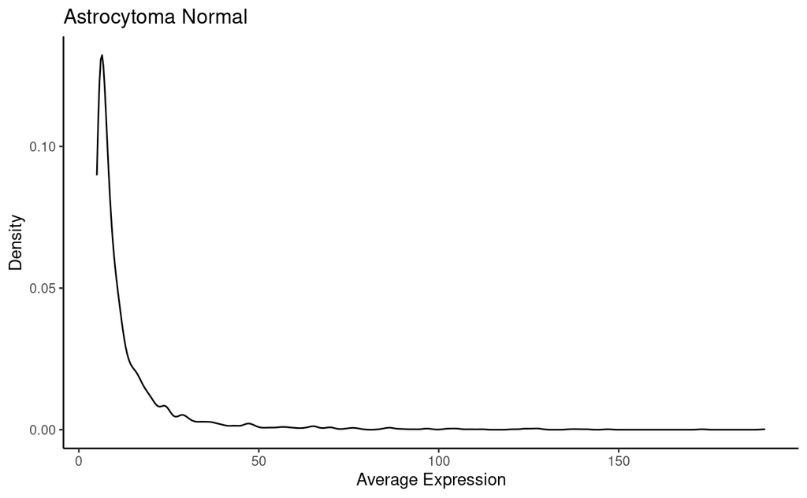

Save your plot as a `PNG`.